# ‘White Wine Quality’ Data Analysis using R by Ng Fang Kiang

# Bivariate Analysis

### Talk about some of the relationships you observed in this part of the investigation. How did the feature(s) of interest vary with other features in the dataset?

An overview, the alcohol and residual sugar value appears to influences the wine quality. Some other’s input variable include free sulfer dioxide, total sulfer dioxide also and density.

# Multivariate Plots Section

I’m used the droped_outlier again.

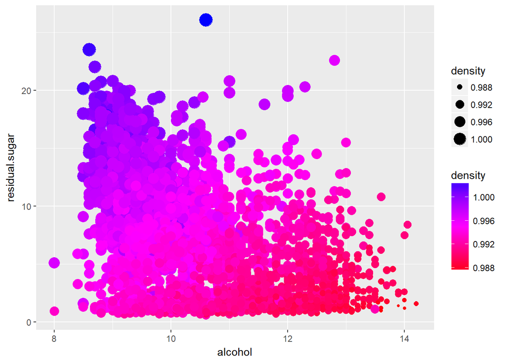

# Multivariate Analysis

### Talk about some of the relationships you observed in this part of the investigation. Were there features that strengthened each other in terms of looking at your feature(s) of interest?Were there any interesting or surprising interactions between features?

The interesting thing I found at the plot is it’s pretty obvious to see the density is getting small when the alcohol is high with low residual sugar.

# Final Plots and Summary

### Plot One

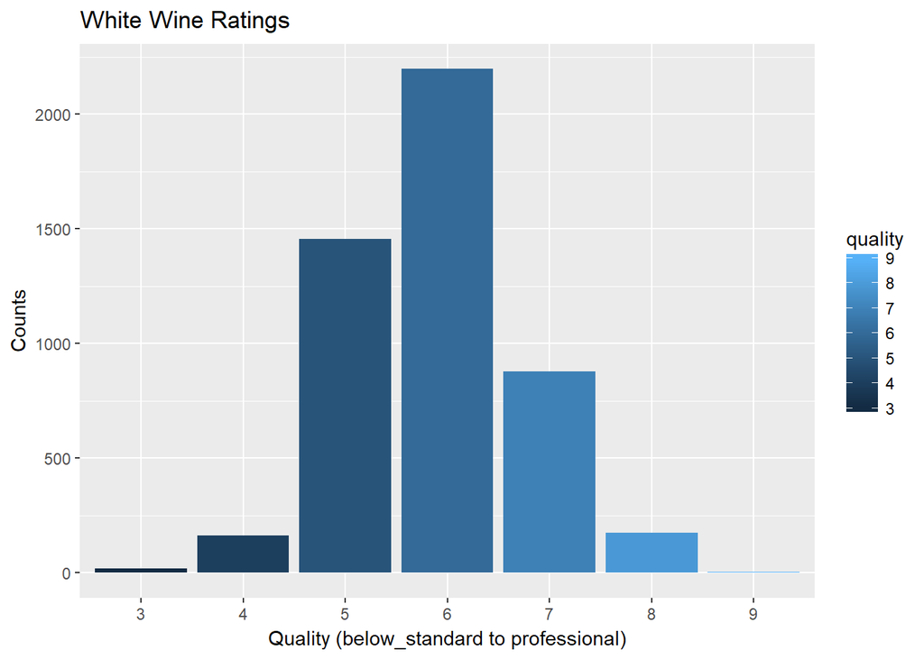

### Description One

According to our analysis, most of the white wines rating is in between of 5 to 7. However, they are only fews record on quality with 3, 4, 8 and 9. There’s some null record on this dataset like quality with 1, 2 and 10.

### Plot Two

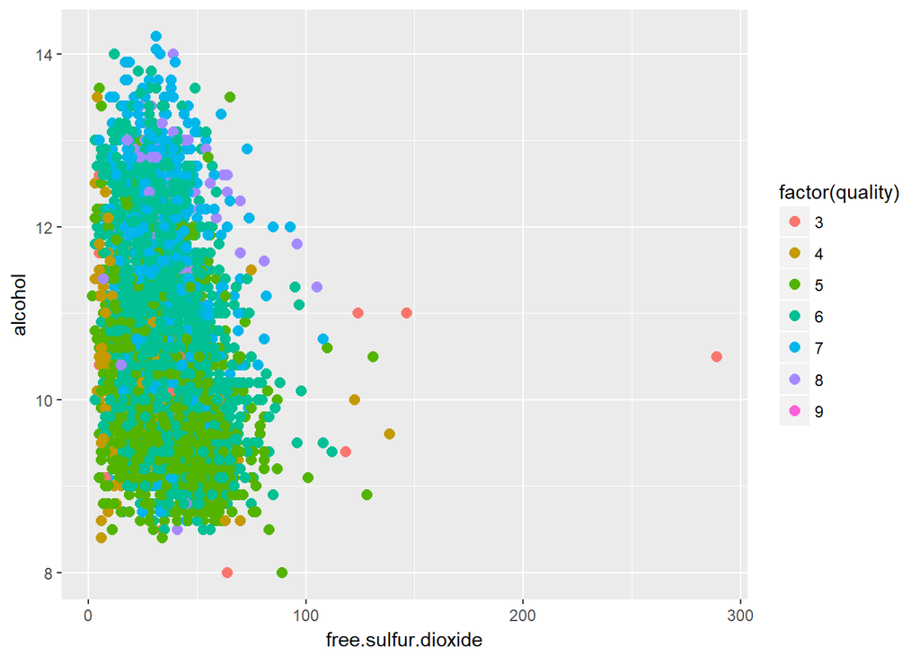

### Description Two

The above plot indicates that for the alcohol and free sulfur dioxide content. The quality of white wines is quite low while the free sulfur dioxide is getting higher. In order to get a high quality white wines, according to this plot seems like we prove again that high alcohol content will influence the quality of white wines. However, the free dioxide should be in the range of 20 to 60 in order to get a good quality.

### Plot Three

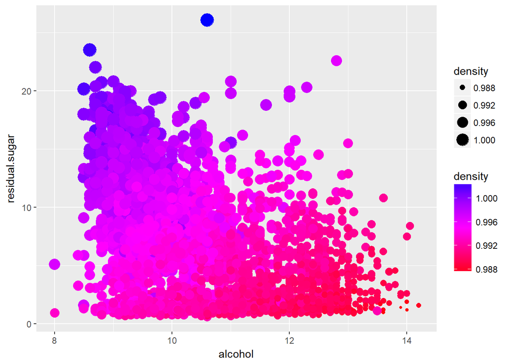

### Description Three

While exploring the correlation of alcohol, residual sugar and density, we found some interesting knowledge of white wines with difference chemical properties. The interesting thing I found at the plot is it’s pretty obvious to see the density is getting small when the alcohol is high with low residual sugar. If you expecting to have low density, increasing the alcohol content and lowering the residual sugar should be good for you and vice visa.

# Reflection

To get myself familiar with this dataset, I began with extracting the structure of this dataset. This dataset contains 4898 records of white wines and 13 features. Since I don’t familiar with this dataset, I try to visualize the dataset from the simplest plot which is histogram. Histogram was doing good to help me get some insight for this dataset. However, to looking for how we get a high quality white wine, I’d visualize some scatterplot to explore the deep insight and get some overview of this. When visualize the dataset, we can’t really see it in depth because of outlier, So, we remove it. Hooray! Now, we do one step closer to this dataset. Last but not least, it’s always good when the alcohol level is around 12 to 14. If you wish to get a good white wines, this is a simplest thing you should do.